# Comercio de anchoveta en el Perú, producción y exportaciones

Actualizado

19 de febrero de 2024

# Objetivos

- Evolución en los últimos 10 años (2014-2023) de las exportaciones de anchoveta de Perú, segmentado por harina de pescado, aceite de pescado, conservas u otros productos.
- Ranking de países a los que se exporta la anchoveta peruana, segmentado por harina de pescado, aceite de pescado, conservas u otros productos, del 2014-2023. Aquí, si es posible, ver si hay reexportación de alguno de estos países hacia otro.
- Ranking de empresas exportadoras de anchoveta peruana, segmentado en harina de pescado, aceite de pescado, conservas u otros productos, de 2014-2023. Ranking de las empresas que importan la anchoveta que sale de Perú, segmentado por harina de pescado, aceite de pescado, conservas u otros productos.
- Principales países exportadores de anchoveta en el mundo. (esto para evidenciar que Perú lidera estas exportaciones).
- Información respecto a los desembarques de pesca anchoveta en puertos peruanos, de 2014-2023. (La idea es conocer cuánto se captura al año, tanto en la pesca industrial como de consumo humano directo).

# Entendiendo los datos

- Según el compendio estadístico del INEI del 2022, los principales tipos de usos en las exportaciones de productos hidrobiologicos son los siguientes, y solo unos cuántos incluyen anchoveta en el desembarque a puertos:
  - Consumo Humano Directo
    - Enlatado: Anchoveta
    - Congelado: No figura anchoveta entre los principales, de hecho no figura la especia entre la llegada de pescados en terminales pesqueros.
    - Curado: Anchoveta
  - Consumo Humano Indirecto
    - Harina de pescado: Anchoveta figura como el único pescado para consumo humano indirecto
    - Aceite crudo de pescado: Anchoveta figura como el único pescado para consumo humano indirecto

Entonces, la anchoveta es usado como el principal insumo para la producción de harina de pescado y aceite de pescado en el Perú.

Entonces, usaremos el código *“030910”*, que se refiere a “Harina, polvo y pellets de de pescado aptos para la alimentación humana.” para analizar *cifras de exportaciones Harina de Pescado - Anchoveta.*. Sin embargo, dicha partida tiene casi ningún registros (apenas 2 envio en 8 años). La partida que más registros tiene es la *“230120”*, que se refiere a “Harina, polvo y «pellets», de pescado o de crustáceos, moluscos o demás invertebrados acuático”

Y usaremos el código *“150420”*, que se refiere a “Grasas y aceites de pescado y sus fracciones, excepto los aceites de hígado:” para analizar *cifras de exportaciones de aciete de pescado - anchoveta*. Sin embargo, tomar en cuenta encontrar cifras de aceite de pesacado congelado y enlatado, ya que esta partida solo correspondería a aceite crudo. Ver notas en observaciones para más detalle.

Para otros productos derivado de anchoveta, usaremos los códigos:

- *“030242”* que se refiere a “Anchoas (Engraulis spp.)”, de la categoría “Pescado fresco o refrigerado”, para *anchoveta fresca o refrigerada*
- *“160416”* que se refiere a “Anchoas”, de la categoría “Preparaciones y conservas de pescado”, para *anchoveta en conservas, enlatados?*
- *“030563”*, que se refiere a “Anchoas(Engraulis spp.)”, de “Pescado salado sin secar ni ahumar y pescado en salmuera, excepto los despojos comestibles”, para *anchoveta curado?*

Para otros tipo de productos base a anchoveta, buscando “anchoveta” en panjiva:

- *“030499”*, que se refiere a “los demás” de “Filetes y demás carne de pescado (incluso picada), frescos, refrigerados o congelados.”
- *“160420”*, que se refiere a “los demás” de “Conservas de pescado”
- *“030539”*, que se refiere a “los demás” de “Pescado seco, salado o en salmuera, ahumado”
- *“030389”*, que se refiere a “los demás” de “demás pescados” de “Pescado congelado, excepto los filetes y demás carne de pescado”
- *“160413”*, que se refiere a “sardinas, sardinelas y espadines” de “Pescado entero o en trozos, excepto el pescado picado” y de “preparaciones y conservas de pescado”. Revisando algunas descripcoiens, aquí exportan:
  - “Anchoveta En Salsa De Tomate Lidita X 24 Und”
  - “Anchoveta Entero En Aceite Girasol Ro.1000 En Cajas Uso Consumo Humano”
  - “Grated De Anchoveta En Agua Y Salmarca A1 En Latasuso: Consumo Humanocodigo”
  - “Anchoveta Entera En Aceite Vegetal 1/4 Club X 25 Und”
- *“030359”*, que se refiere a “los demás”, de “una lista de pescados(incluye y define anchoas)” de “pescado congelado excepto los filetes y demás carne de pescado” También hay estas partidas que pueden referirse a harina de pescado?

# Observaciones, notas

Hay unas cifras que no me cuadran. Según el compendio estadísticos del INEI del 2022, se muestra el siguiente cuadro respecto a exportacoines de Aceite de pescado en el 2022

| Aceite crudo | aceite congelado | aceite enlatado |
| --- | --- | --- |
| 150.354 | 426.604 | 18.257 |

Pero las cifras del [anuario estadístico de Produce](https://ogeiee.produce.gob.pe/index.php/en/shortcode/oee-documentos-publicaciones/publicaciones-anuales/item/1116-anuario-estadistico-pesquero-y-acuicola-2022), de la misma oficina que tiene como fuente el INEI: Oficina General de Evaluación de Impacto y Estudios Económicos muestra que en el 2022 solo se exportaron 94.806 toneladas de aceite crudo. Tampoco en Sunat he podido encontrar cifras de aceite congelado o enlatado para poder comparar.

# Evolución de exportaciones de Anchoveta

Según el Ministerio de Producción (Produce), en el 2022 se exportaron 1,8 millones de toneladas métricas en productos de pesca marítima.

Si lo comparamos en las cifras de exportaciones de Anchovoeta, quiere decir que el 71% de todo lo exportado de productos pesqueros provienen de la anchoveta y sus derivados: harina, aceite, enlatados, conservas, entre otros. Es decir, la anchoveta es una especie con gran presencia en el sector pesquero peruano.

Esta predominancia se ha mantenido al menos desde el 2015 según los datos disponibles, siendo los picos los año 2017 y 2018, donde la anchoveta representó el 76% de todos los producto hidrobiológicos exportados.

**Por peso bruto TM**

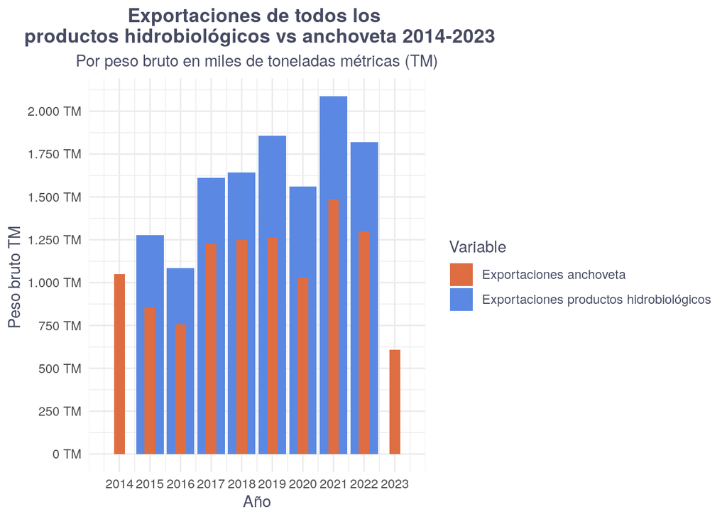

Exportaciones de todos los productos hidrobiológicos vs anchoveta 2014-2023

Por peso bruto en miles de toneladas métricas (TM) 2014-2023

| variable | 2014 | 2015 | 2016 | 2017 | 2018 | 2019 | 2020 | 2021 | 2022 | 2023 |
| --- | --- | --- | --- | --- | --- | --- | --- | --- | --- | --- |
| Exportaciones productos hidrobiologicos | 0 | 1.276 | 1.084 | 1.611 | 1.643 | 1.857 | 1.559 | 2.088 | 1.820 | 0 |
| Exportaciones anchoveta | 1.050 | 853 | 755 | 1.228 | 1.249 | 1.266 | 1.031 | 1.488 | 1.299 | 609 |

**Por porcentaje**

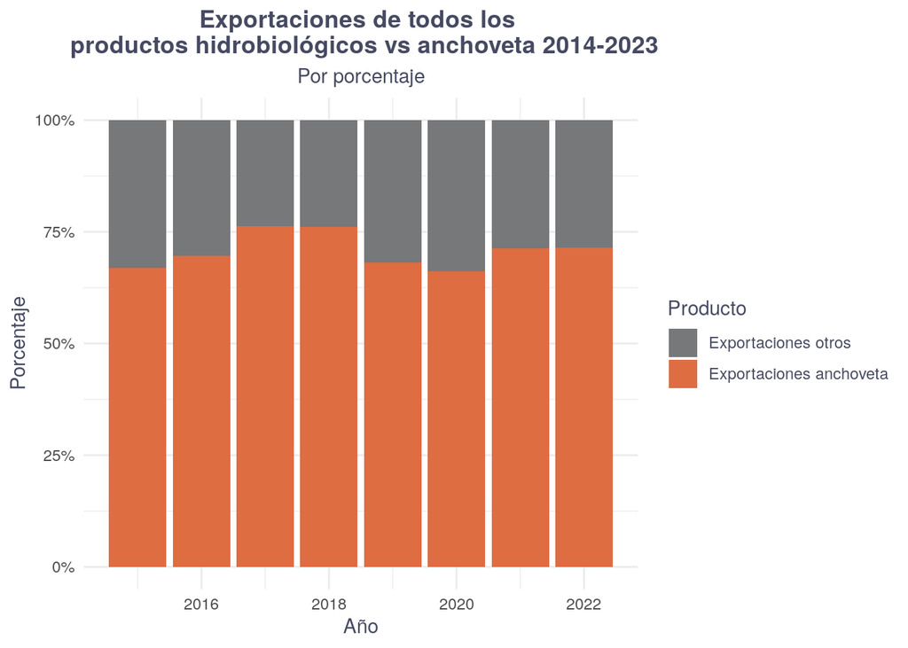

Exportaciones de todos los productos hidrobiológicos vs anchoveta 2014-2023

Por porcentaje

| Año | Porcentaje otros productos hidrobiológicos | Porcentaje anchoveta |
| --- | --- | --- |
| 2022 | 29% | 71% |
| 2021 | 29% | 71% |
| 2020 | 34% | 66% |
| 2019 | 32% | 68% |
| 2018 | 24% | 76% |
| 2017 | 24% | 76% |
| 2016 | 30% | 70% |
| 2015 | 33% | 67% |

Si examinamos exclusivamente las exportaciones de anchoveta y sus productos derivados, observamos una tendencia al alza desde 2017, experimentando un marcado descenso en 2020 debido a la pandemia. Sin embargo, en el año siguiente, las exportaciones se incrementaron notablemente, alcanzando un máximo histórico en 2021. Posteriormente, se registró una disminución progresiva hasta 2023. Este último año marcó el nivel más bajo en la historia de las exportaciones de anchoveta, con aproximadamente 609 mil toneladas métricas, lo que representa una reducción del 53,6% en comparación con el año 2022.

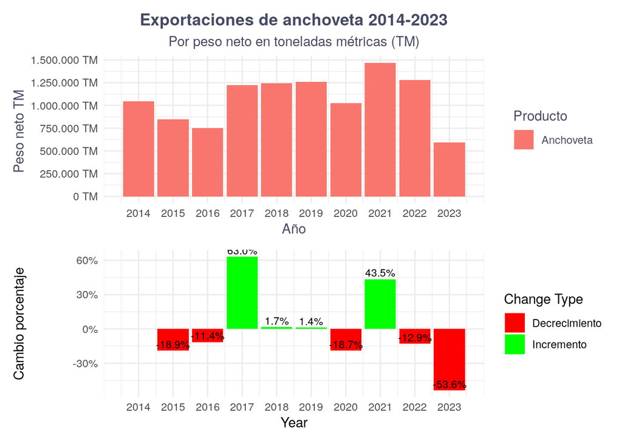

De toda la anchoveta exportada por Perú, el principal producto derivado de esta especie es la harina de pescado.

**Peso neto TM**

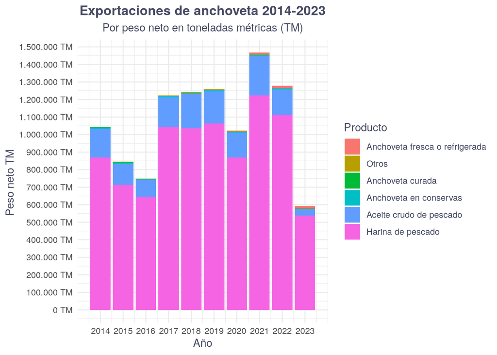

Exportaciones de Anchoveta

Por peso neto en toneladas métricas (TM) 2014-2023

| Producto | 2014 | 2015 | 2016 | 2017 | 2018 | 2019 | 2020 | 2021 | 2022 | 2023 |
| --- | --- | --- | --- | --- | --- | --- | --- | --- | --- | --- |
| Harina de pescado | 870.146 | 713.708 | 644.455 | 1.041.525 | 1.034.924 | 1.062.843 | 869.915 | 1.223.822 | 1.111.661 | 537.284 |
| Aceite crudo de pescado | 163.487 | 118.776 | 95.054 | 171.086 | 195.983 | 183.870 | 140.160 | 224.661 | 146.486 | 35.585 |
| Anchoveta fresca o refrigerada | 10 | NA | 0 | NA | 423 | 884 | 3.820 | 10.235 | 13.557 | 14.932 |
| Anchoveta en conservas | 6.845 | 7.718 | 6.143 | 6.052 | 6.587 | 6.292 | 5.302 | 6.436 | 4.735 | 3.998 |
| Otros | 1.610 | 2.543 | 3.142 | 2.619 | 3.870 | 4.942 | 3.579 | 2.662 | 2.029 | 1.482 |
| Anchoveta curada | 1.794 | 3.718 | 943 | 1.109 | 1.180 | 958 | 952 | 982 | 485 | 273 |

**Valor FOB USD**

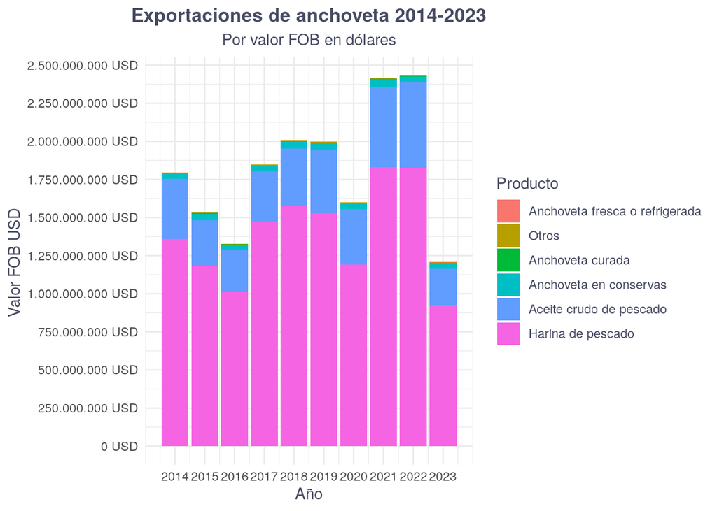

Exportaciones de Anchoveta

Por valor FOB en millones de dólares

| Producto | 2014 | 2015 | 2016 | 2017 | 2018 | 2019 | 2020 | 2021 | 2022 | 2023 |
| --- | --- | --- | --- | --- | --- | --- | --- | --- | --- | --- |
| Harina de pescado | 1.360 | 1.182 | 1.014 | 1.475 | 1.579 | 1.527 | 1.193 | 1.830 | 1.825 | 926 |
| Aceite crudo de pescado | 395 | 300 | 270 | 329 | 375 | 420 | 361 | 528 | 564 | 238 |
| Anchoveta en conservas | 33 | 43 | 37 | 36 | 45 | 40 | 38 | 50 | 36 | 38 |
| Anchoveta fresca o refrigerada | 0 | NA | 0 | NA | 0 | 0 | 1 | 2 | 2 | 3 |
| Otros | 3 | 5 | 6 | 4 | 6 | 8 | 5 | 4 | 3 | 3 |
| Anchoveta curada | 4 | 7 | 2 | 3 | 4 | 3 | 2 | 3 | 1 | 1 |

# Notas y observaciones:

# Referencias

- [Exportaciones de harina de pescado en 2023](https://peru.oceana.org/blog/informe-las-exportaciones-de-harina-de-pescado-en-el-2023/)
- [Comercio ilegal de anchoveta - 2017](https://peru.oceana.org/wp-content/uploads/sites/22/anchoveta_corregido2_0.pdf)